# Udacity Nano Degree Program- Data Scientist for Enterprise

## Author: Durga Parida

### Project CAPSTONE PROJECT- BANK TERM DEPOSIT OFFER CAMPAIGN

### Problem Statement:

The data is related with direct marketing campaigns (phone calls) of a Portuguese banking institution. The classification goal is to predict if the client will subscribe (yes/no) a term deposit (Response variable).

#### In this project, we will design and deploy a supervised Model(such as Logistics regression) to predict if a Customer will subscribe to a term deposit campaign or not

### Solution Approach:

We will be using Supervised Learning Binary Classification Model, i.e. Logistic regression to predict if the Customer will accept the term deposit offer or not.

Logistic Regression is one of the most valuable machine learning model and is mainly used when the dependent variable is categorical. In our case, term_deposit value is a categorical variable(Yes/No)

### The notebook will be broken down into a few steps usinG CRISP-DM Approach:

#### 1. Business Understanding

#### 2. Data Understanding

```
 -Handle Missing Data
 -Exploratory Visualization
```

#### 3. Data Pre-Processing

```
 -Feature Engineering and Data Transformation
```

#### 4. Model Data

```
  -Splitting the data into train/test sets
  -Defining and training Logistics regression Model
  -Evaluate and Validate the Model
  -Test the Model
```

#### 5. Analyze Results

Import required Packages

## Section 1- Business Goal

The data is related with direct marketing campaigns (phone calls) of a Portuguese banking institution. The classification goal is to predict if the client will subscribe (yes/no) a term deposit (Response variable).

### import necessary packages

```python
import io
import os
import numpy as np
import pandas as pd

import matplotlib.pyplot as plt
import seaborn as sns

from sklearn.linear_model import LogisticRegression
from sklearn.model_selection import GridSearchCV
from sklearn import metrics
from sklearn.metrics import confusion_matrix
from sklearn.metrics import accuracy_score
from sklearn.metrics import balanced_accuracy_score
from sklearn.metrics import classification_report


# Installl mixtend via one of the following approach:
#1. Conda: conda install mixtend
#2. from PyPI- pip install mixtend
#3. Dev version: pip install git+git://github.com/rasbt/mlxtend.git

from mlxtend.plotting import plot_confusion_matrix
```

### -----------------------------------------------------------------------------------------------------------------------------------------------------

## Section 2- Data Understanding

```python
# read in the csv file
bank_data = 'bank_marketing_data.csv'

# print out some data
bank_df = pd.read_csv(bank_data)
print('Data shape (rows, cols): ', bank_df.shape)
print()
bank_df.head()
```

```
Data shape (rows, cols):  (45211, 17)
```

|  | age | job | marital | education | default | balance | housing | loan | contact | day | month | duration | campaign | pdays | previous | poutcome | term_deposit |
| --- | --- | --- | --- | --- | --- | --- | --- | --- | --- | --- | --- | --- | --- | --- | --- | --- | --- |
| 0 | 58 | management | married | tertiary | no | 2143 | yes | no | unknown | 5 | may | 261 | 1 | -1 | 0 | unknown | no |
| 1 | 44 | technician | single | secondary | no | 29 | yes | no | unknown | 5 | may | 151 | 1 | -1 | 0 | unknown | no |
| 2 | 33 | entrepreneur | married | secondary | no | 2 | yes | yes | unknown | 5 | may | 76 | 1 | -1 | 0 | unknown | no |
| 3 | 47 | blue-collar | married | unknown | no | 1506 | yes | no | unknown | 5 | may | 92 | 1 | -1 | 0 | unknown | no |
| 4 | 33 | unknown | single | unknown | no | 1 | no | no | unknown | 5 | may | 198 | 1 | -1 | 0 | unknown | no |

```python
# Data Set- Columns namess, data types
bank_df.info()
```

```
<class 'pandas.core.frame.DataFrame'>
RangeIndex: 45211 entries, 0 to 45210
Data columns (total 17 columns):
age             45211 non-null int64
job             45211 non-null object
marital         45211 non-null object
education       45211 non-null object
default         45211 non-null object
balance         45211 non-null int64
housing         45211 non-null object
loan            45211 non-null object
contact         45211 non-null object
day             45211 non-null int64
month           45211 non-null object
duration        45211 non-null int64
campaign        45211 non-null int64
pdays           45211 non-null int64
previous        45211 non-null int64
poutcome        45211 non-null object
term_deposit    45211 non-null object
dtypes: int64(7), object(10)
memory usage: 5.9+ MB
```

```python
# Display the number of records and features.

print ("Rows     : " ,bank_df.shape[0])
print ("Columns  : " ,bank_df.shape[1])
print ("\nFeatures : \n" ,bank_df.columns.tolist())
print ("\nMissing values :  ", bank_df.isnull().sum().values.sum())
```

```
Rows     :  45211
Columns  :  17

Features :
 ['age', 'job', 'marital', 'education', 'default', 'balance', 'housing', 'loan', 'contact', 'day', 'month', 'duration', 'campaign', 'pdays', 'previous', 'poutcome', 'term_deposit']

Missing values :   0
```

```python
# Insight about values in the numerical columns.
bank_df.describe()
```

|  | age | balance | day | duration | campaign | pdays | previous |
| --- | --- | --- | --- | --- | --- | --- | --- |
| count | 45211.000000 | 45211.000000 | 45211.000000 | 45211.000000 | 45211.000000 | 45211.000000 | 45211.000000 |
| mean | 40.936210 | 1362.272058 | 15.806419 | 258.163080 | 2.763841 | 40.197828 | 0.580323 |
| std | 10.618762 | 3044.765829 | 8.322476 | 257.527812 | 3.098021 | 100.128746 | 2.303441 |
| min | 18.000000 | -8019.000000 | 1.000000 | 0.000000 | 1.000000 | -1.000000 | 0.000000 |
| 25% | 33.000000 | 72.000000 | 8.000000 | 103.000000 | 1.000000 | -1.000000 | 0.000000 |
| 50% | 39.000000 | 448.000000 | 16.000000 | 180.000000 | 2.000000 | -1.000000 | 0.000000 |
| 75% | 48.000000 | 1428.000000 | 21.000000 | 319.000000 | 3.000000 | -1.000000 | 0.000000 |
| max | 95.000000 | 102127.000000 | 31.000000 | 4918.000000 | 63.000000 | 871.000000 | 275.000000 |

#### Handle Missing data

```python
# Get total count of NaN in Data Frame
nan_cnt = bank_df.isnull().sum().sum()
print(" Total Nan count", nan_cnt)

nan_rows = bank_df.shape[0] - bank_df.dropna().shape[0]
print("# of Rows with Nan", nan_rows)

# drop rows with NaN Values
clean_bank_df = bank_df.dropna(axis = 0)
print('(clean-1) rows, cols: ', clean_bank_df.shape)
```

```
 Total Nan count 0
# of Rows with Nan 0
(clean-1) rows, cols:  (45211, 17)
```

```python
# take a look at Cleaned Bank Data Frame
clean_bank_df.head(10)
```

|  | age | job | marital | education | default | balance | housing | loan | contact | day | month | duration | campaign | pdays | previous | poutcome | term_deposit |
| --- | --- | --- | --- | --- | --- | --- | --- | --- | --- | --- | --- | --- | --- | --- | --- | --- | --- |
| 0 | 58 | management | married | tertiary | no | 2143 | yes | no | unknown | 5 | may | 261 | 1 | -1 | 0 | unknown | no |
| 1 | 44 | technician | single | secondary | no | 29 | yes | no | unknown | 5 | may | 151 | 1 | -1 | 0 | unknown | no |
| 2 | 33 | entrepreneur | married | secondary | no | 2 | yes | yes | unknown | 5 | may | 76 | 1 | -1 | 0 | unknown | no |
| 3 | 47 | blue-collar | married | unknown | no | 1506 | yes | no | unknown | 5 | may | 92 | 1 | -1 | 0 | unknown | no |
| 4 | 33 | unknown | single | unknown | no | 1 | no | no | unknown | 5 | may | 198 | 1 | -1 | 0 | unknown | no |
| 5 | 35 | management | married | tertiary | no | 231 | yes | no | unknown | 5 | may | 139 | 1 | -1 | 0 | unknown | no |
| 6 | 28 | management | single | tertiary | no | 447 | yes | yes | unknown | 5 | may | 217 | 1 | -1 | 0 | unknown | no |
| 7 | 42 | entrepreneur | divorced | tertiary | yes | 2 | yes | no | unknown | 5 | may | 380 | 1 | -1 | 0 | unknown | no |
| 8 | 58 | retired | married | primary | no | 121 | yes | no | unknown | 5 | may | 50 | 1 | -1 | 0 | unknown | no |
| 9 | 43 | technician | single | secondary | no | 593 | yes | no | unknown | 5 | may | 55 | 1 | -1 | 0 | unknown | no |

The dataset has no missing values/NaNs For accurate predictions, let's select the significant predictors by choosing the features that most affect the output-term_deposit acceptance.

```python
# Distribution of  Response /target variable

clean_bank_df['term_deposit'].value_counts()
```

```
no     39922
yes     5289
Name: term_deposit, dtype: int64
```

```python
# pairwise correlation of numerical predictor variables

clean_bank_df.corr()
```

|  | age | balance | day | duration | campaign | pdays | previous |
| --- | --- | --- | --- | --- | --- | --- | --- |
| age | 1.000000 | 0.097783 | -0.009120 | -0.004648 | 0.004760 | -0.023758 | 0.001288 |
| balance | 0.097783 | 1.000000 | 0.004503 | 0.021560 | -0.014578 | 0.003435 | 0.016674 |
| day | -0.009120 | 0.004503 | 1.000000 | -0.030206 | 0.162490 | -0.093044 | -0.051710 |
| duration | -0.004648 | 0.021560 | -0.030206 | 1.000000 | -0.084570 | -0.001565 | 0.001203 |
| campaign | 0.004760 | -0.014578 | 0.162490 | -0.084570 | 1.000000 | -0.088628 | -0.032855 |
| pdays | -0.023758 | 0.003435 | -0.093044 | -0.001565 | -0.088628 | 1.000000 | 0.454820 |
| previous | 0.001288 | 0.016674 | -0.051710 | 0.001203 | -0.032855 | 0.454820 | 1.000000 |

### Section 2(b)- Exploratory Visualization

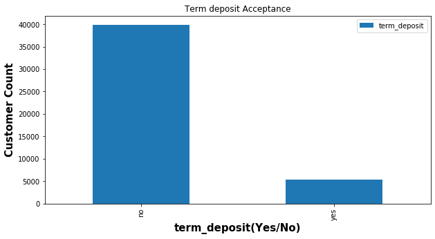

```python
# Check target Variable distribution
# This is imbalanced data set.

ax = clean_bank_df["term_deposit"].value_counts().plot(kind='bar', title ="Term deposit Acceptance", figsize=(10, 5), legend=True, fontsize=10)
ax.set_xlabel("Hour", fontsize=12)
ax.set_xlabel("term_deposit(Yes/No)",fontsize = 15,weight='bold')
ax.set_ylabel("Customer Count",fontsize = 15,weight='bold')
plt.show()
```

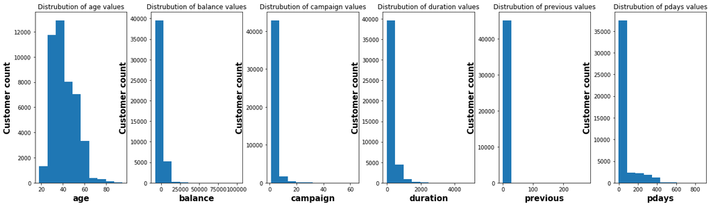

```python
# Histograms - Distribution of  Numeric columns.

f, ((ax1, ax2, ax3, ax4, ax5,ax6)) = plt.subplots(1, 6, figsize=(18,5))
f.tight_layout()
ax = [ax1, ax2, ax3, ax4, ax5, ax6]
num_feat = ['age', 'balance', 'campaign', 'duration','previous', 'pdays']
for i in range (len(ax)):
    x_hist = bank_df[num_feat[i]]

    ax[i].hist(x = x_hist, bins = 10)
    ax[i].set_xlabel(num_feat[i],fontsize = 15, weight='bold')
    ax[i].set_ylabel("Customer count", fontsize = 15, weight='bold')
    ax[i].set_title('Distrubution of ' + num_feat[i] + ' values')
```

```python
clean_bank_df.head()
```

|  | age | job | marital | education | default | balance | housing | loan | contact | day | month | duration | campaign | pdays | previous | poutcome | term_deposit |
| --- | --- | --- | --- | --- | --- | --- | --- | --- | --- | --- | --- | --- | --- | --- | --- | --- | --- |
| 0 | 58 | management | married | tertiary | no | 2143 | yes | no | unknown | 5 | may | 261 | 1 | -1 | 0 | unknown | no |
| 1 | 44 | technician | single | secondary | no | 29 | yes | no | unknown | 5 | may | 151 | 1 | -1 | 0 | unknown | no |
| 2 | 33 | entrepreneur | married | secondary | no | 2 | yes | yes | unknown | 5 | may | 76 | 1 | -1 | 0 | unknown | no |
| 3 | 47 | blue-collar | married | unknown | no | 1506 | yes | no | unknown | 5 | may | 92 | 1 | -1 | 0 | unknown | no |
| 4 | 33 | unknown | single | unknown | no | 1 | no | no | unknown | 5 | may | 198 | 1 | -1 | 0 | unknown | no |

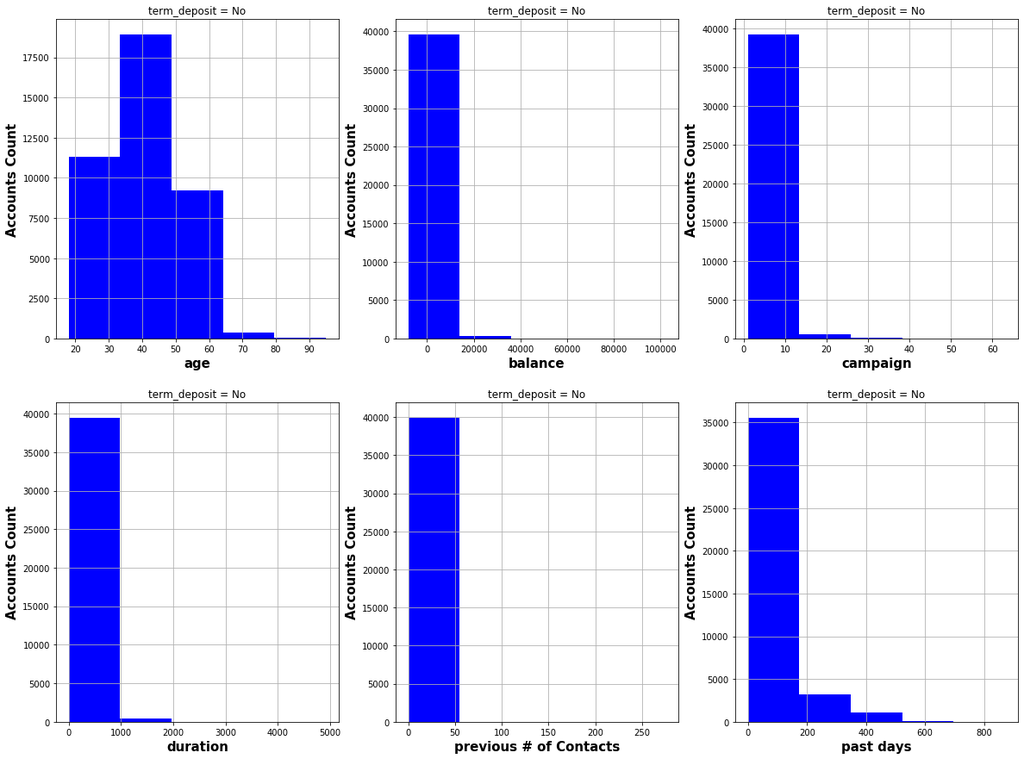

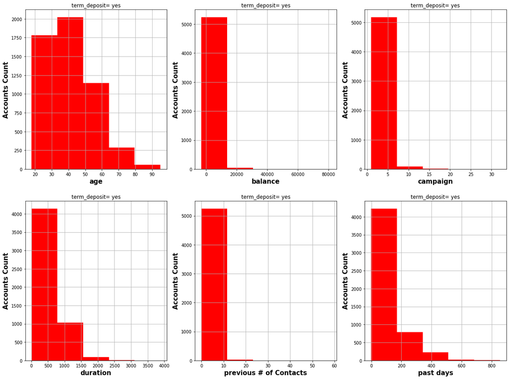

```python
def hist_num_td(num_list, num_title, td_flag):
    '''
    Purpose:  Plots the Histograms of Numerical Variables in relation to term_deposit indicator -yes/no

    INPUT
    List 1 - Containing the numerical predictor variables
    List 2 - Containing the Plot axis title for numerical predictor variables
    td_flag - term_deposit_flag- Yes or No

    OUTPUT
    Historgrams of Numerical variables distribution with respect to term_deposit Indicator(yes/no)

    '''

    flag = td_flag
    ROWS, COLS = 2,3
    fig, ax = plt.subplots(ROWS,COLS, figsize=(20,15))

    if flag == "no":
        plot_title = "term_deposit = No"
        my_color= "blue"
    else:
        plot_title = "term_deposit= yes"
        my_color= "red"


    num = 0
    row, col = 0, 0
    for i, num_feat in enumerate(num_list):
        if col == COLS - 1:
            row += 1
        col = i % COLS

        clean_bank_df[clean_bank_df.term_deposit == flag][num_feat].hist(bins= 5, color=my_color, alpha=1.0, ax=ax[row,col]).set_title(plot_title)
        ax[row,col].set_xlabel(num_title[i],fontsize = 15,weight='bold')
        ax[row,col].set_ylabel("Accounts Count",fontsize = 15, weight='bold')
        num += 1

    return

# Plot the Histogram for Numeric Variable with respect to term deposit Flag = "No"
num_list = ['age', 'balance', 'campaign', 'duration','previous', 'pdays']
num_title= ['age', 'balance', 'campaign', 'duration','previous # of Contacts', 'past days']


td_flag = "no"
hist_num_td(num_list, num_title, td_flag)

# Plot the Histogram for Numeric Variable with respect to term deposit  Flag = "Yes"
td_flag = "yes"
hist_num_td(num_list, num_title, td_flag)

# Obeservations*
```

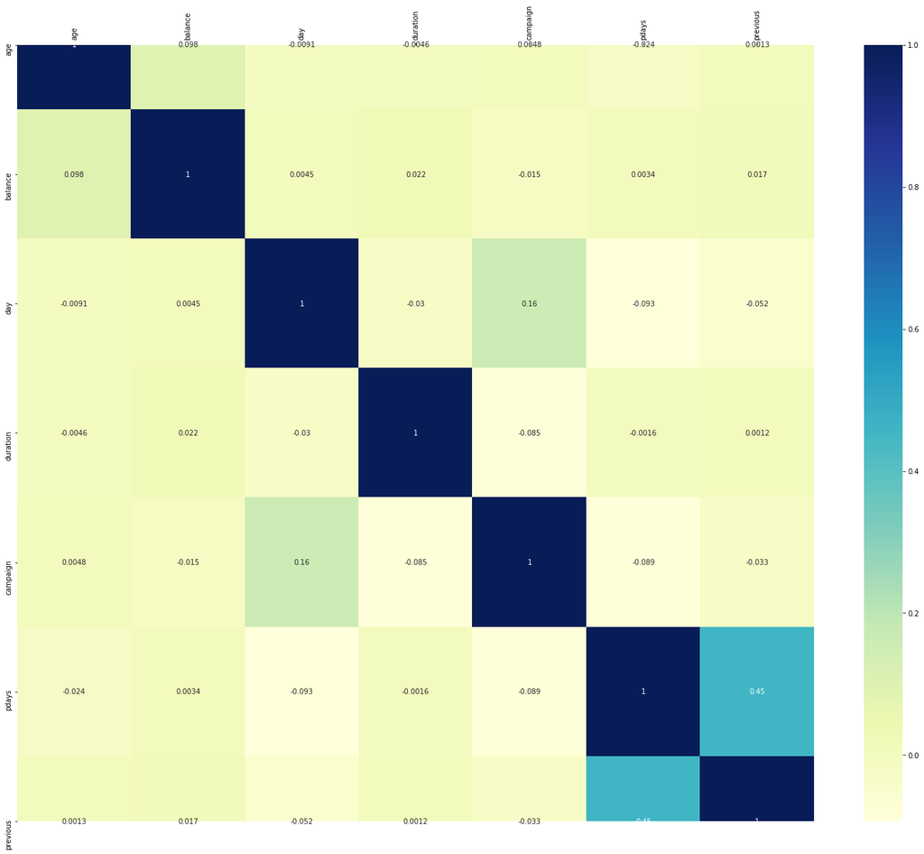

```python
#plot a correlation heatmap
#This correlation heatmap helps with feature selection because the gradient shows the correlation between the columns of the dataframe.
#We can select only the significant predictors by eliminating the features that are highly correlated with each other (ex: 0.95).

plt.subplots(figsize=(25,20))
hm1 = sns.heatmap(clean_bank_df.corr(), annot=True, cmap='YlGnBu')
hm1.set_xticklabels(hm1.get_xticklabels(), rotation=90)
hm1.xaxis.set_ticks_position('top')
```

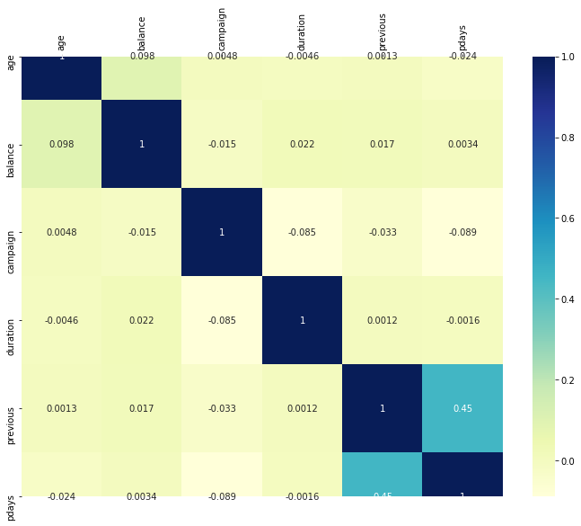

```python
# Plot correlation heatmap of selected numerical features/predictor variables.

plt.subplots(figsize=(12, 9))
hm2 = sns.heatmap(clean_bank_df[['age', 'balance', 'campaign', 'duration', 'previous', 'pdays']].corr(), annot=True, cmap='YlGnBu')
hm2.set_xticklabels(hm2.get_xticklabels(), rotation=90)
hm2.xaxis.set_ticks_position('top')
```

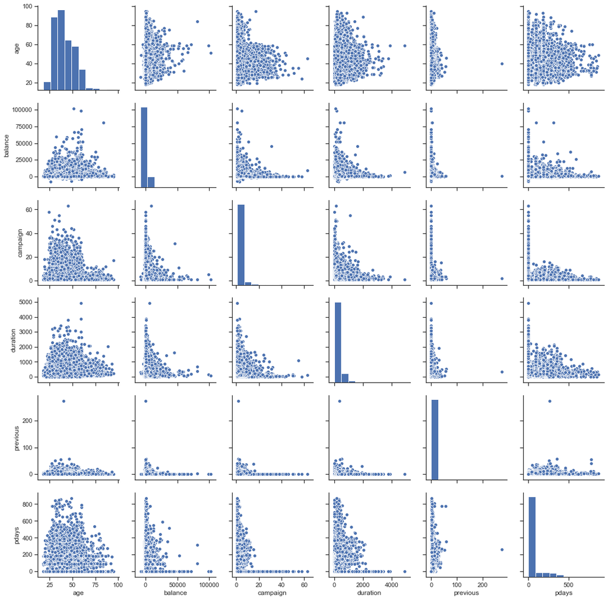

```python
# Visualizing pairwise relationship in a data set in Seaborn
#The pairs plot builds on two basic figures, the histogram and the scatter plot.
#The histogram on the diagonal allows us to see the distribution of a single variable
#while the scatter plots on the upper and lower triangles show the relationship (or lack thereof) between two variables

sns.set(style="ticks", color_codes=True)
sns.pairplot(clean_bank_df,vars=["age", "balance", "campaign","duration", "previous", "pdays"])
```

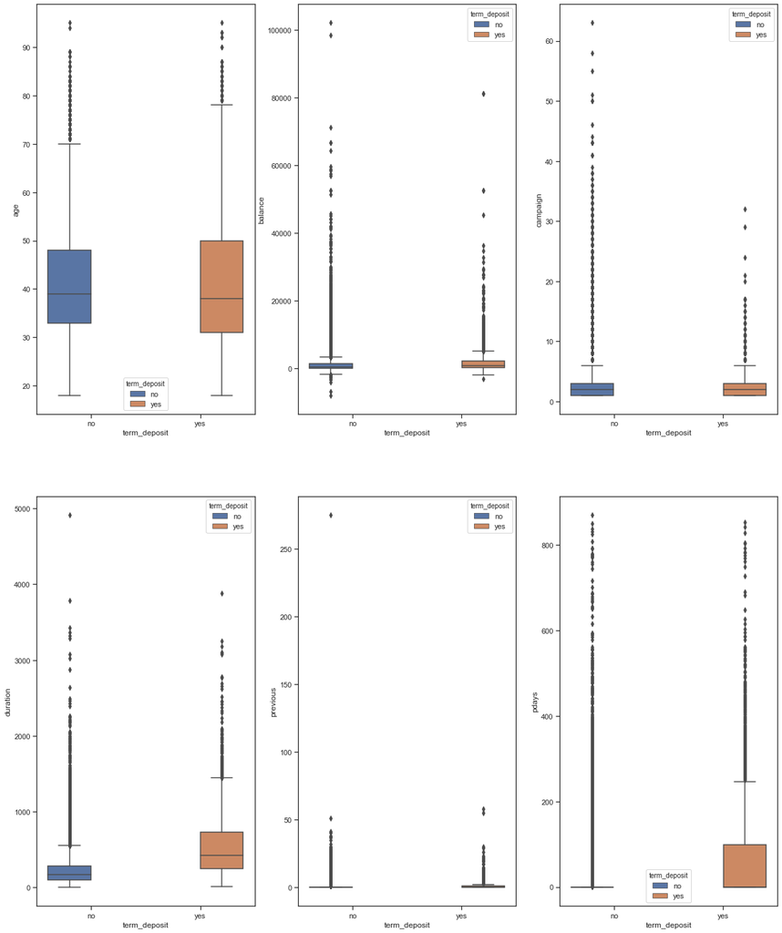

```python
# plot boxplots of numerical columns
# For predicting the labels/response variable9term_deposit),
# the most significant predictors can be found by plotting boxplots of the numerical values against the labels.
# The features with boxplots that show the most variance should be chosen as the predictors for your model.

# This plots can detect the outliers as well.


num_list = ['age', 'balance', 'campaign', 'duration','previous', 'pdays']
f, ((ax1, ax2,ax3), (ax4, ax5, ax6)) = plt.subplots(2, 3, figsize=(20, 25))
ax = [ax1, ax2, ax3, ax4, ax5, ax6]

for i in range(len(num_list)):
    sns.boxplot(x = 'term_deposit', y = num_list[i], hue="term_deposit",data=clean_bank_df, ax=ax[i])
```

[output not shown]

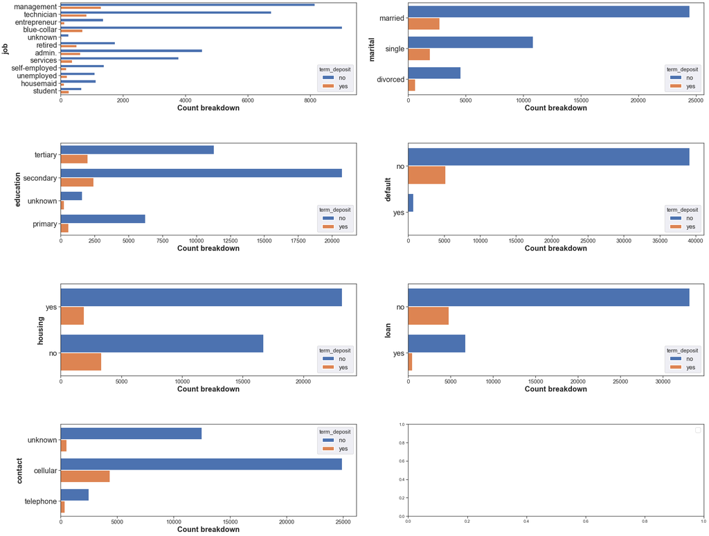

```python
# Data Visualization-Bar Chart of Categorical Variables with respect to term_deposit Response Variable

cat_feat = ['job', 'marital', 'education', 'default','housing', 'loan','contact']

ROWS, COLS = 4, 2
fig, ax = plt.subplots(ROWS, COLS, figsize=(25, 20))
plt.legend(fontsize='x-large', title_fontsize='40')
fig.tight_layout(h_pad=9, w_pad=9)
sns.set(font_scale= 1.45)

row, col = 0, 0
for i, cat_feat in enumerate(cat_feat):
    if col == COLS - 1:
        row += 1
    col = i % COLS

    sns.countplot(y = cat_feat, hue='term_deposit', data = clean_bank_df, ax= ax[row,col],saturation =1,linewidth=2)
  #  sns.catplot(y = cat_feat, hue='term_deposit', kind="count",data = clean_bank_df, ax= ax[row,col],saturation =1,linewidth=2)

    ax[row,col].set_ylabel(cat_feat,fontsize = 20,weight = 'bold')
    ax[row,col].set_xlabel("Count breakdown",fontsize = 20, weight = 'bold')
    ax[row,col].tick_params(axis = "x", labelsize = 15)
    ax[row,col].tick_params(axis = "y", labelsize = 20)
```

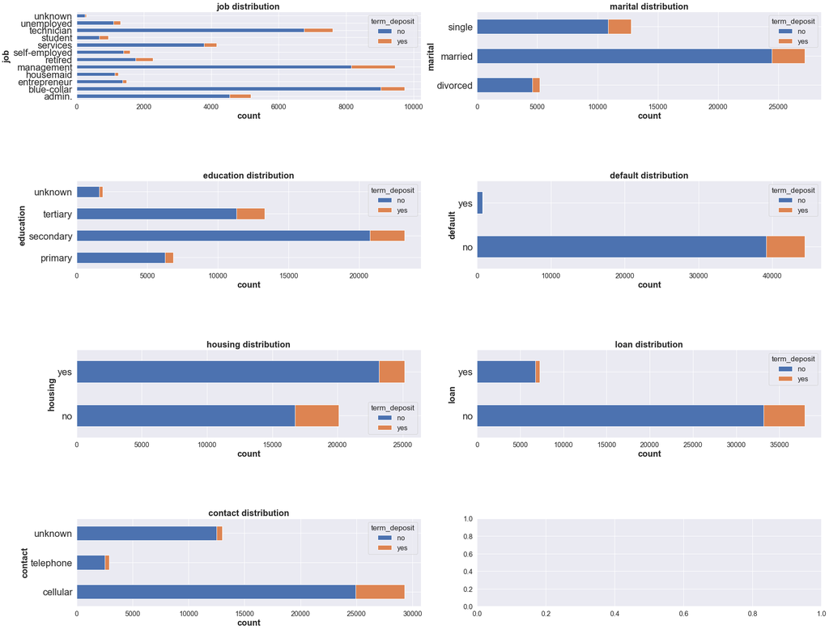

```python
# Data Visualization- Stacked Bar Chart of Categorical Variable with respect to term_deposit Response Variable

cat_feat = ['job', 'marital', 'education', 'default','housing', 'loan','contact']

ROWS, COLS = 4, 2
fig, ax = plt.subplots(ROWS, COLS, figsize=(25, 20))
fig.tight_layout(h_pad=9, w_pad=5)

row, col = 0, 0
for i, cat_feat in enumerate(cat_feat):
    if col == COLS - 1:
        row += 1
    col = i % COLS

    df = clean_bank_df.groupby([cat_feat,'term_deposit']).size().unstack()
    df.plot(kind= 'barh', stacked=True ,ax=ax[row, col]).set_title(cat_feat + ' distribution',fontsize = 20, weight = 'bold' )
    ax[row,col].set_xlabel("count",fontsize = 20,weight = 'bold')
    ax[row,col].set_ylabel(cat_feat ,fontsize = 20, weight = 'bold')
    ax[row,col].tick_params(axis = "y", labelsize = 22)
```

```python
# take a look at Cleaned Bank Data Frame
clean_bank_df.head(10)
```

|  | age | job | marital | education | default | balance | housing | loan | contact | day | month | duration | campaign | pdays | previous | poutcome | term_deposit |
| --- | --- | --- | --- | --- | --- | --- | --- | --- | --- | --- | --- | --- | --- | --- | --- | --- | --- |
| 0 | 58 | management | married | tertiary | no | 2143 | yes | no | unknown | 5 | may | 261 | 1 | -1 | 0 | unknown | no |
| 1 | 44 | technician | single | secondary | no | 29 | yes | no | unknown | 5 | may | 151 | 1 | -1 | 0 | unknown | no |
| 2 | 33 | entrepreneur | married | secondary | no | 2 | yes | yes | unknown | 5 | may | 76 | 1 | -1 | 0 | unknown | no |
| 3 | 47 | blue-collar | married | unknown | no | 1506 | yes | no | unknown | 5 | may | 92 | 1 | -1 | 0 | unknown | no |
| 4 | 33 | unknown | single | unknown | no | 1 | no | no | unknown | 5 | may | 198 | 1 | -1 | 0 | unknown | no |
| 5 | 35 | management | married | tertiary | no | 231 | yes | no | unknown | 5 | may | 139 | 1 | -1 | 0 | unknown | no |
| 6 | 28 | management | single | tertiary | no | 447 | yes | yes | unknown | 5 | may | 217 | 1 | -1 | 0 | unknown | no |
| 7 | 42 | entrepreneur | divorced | tertiary | yes | 2 | yes | no | unknown | 5 | may | 380 | 1 | -1 | 0 | unknown | no |
| 8 | 58 | retired | married | primary | no | 121 | yes | no | unknown | 5 | may | 50 | 1 | -1 | 0 | unknown | no |
| 9 | 43 | technician | single | secondary | no | 593 | yes | no | unknown | 5 | may | 55 | 1 | -1 | 0 | unknown | no |

```python
# Drop Irrelevant Columns- Day, month
drop=["day" ,"month"]
clean_bank_df = clean_bank_df.drop(columns=drop)

print(clean_bank_df.dtypes)

print(clean_bank_df.isnull().sum().sum())

clean_bank_df.head(10)
```

```
age              int64
job             object
marital         object
education       object
default         object
balance          int64
housing         object
loan            object
contact         object
duration         int64
campaign         int64
pdays            int64
previous         int64
poutcome        object
term_deposit    object
dtype: object
0
```

|  | age | job | marital | education | default | balance | housing | loan | contact | duration | campaign | pdays | previous | poutcome | term_deposit |
| --- | --- | --- | --- | --- | --- | --- | --- | --- | --- | --- | --- | --- | --- | --- | --- |
| 0 | 58 | management | married | tertiary | no | 2143 | yes | no | unknown | 261 | 1 | -1 | 0 | unknown | no |
| 1 | 44 | technician | single | secondary | no | 29 | yes | no | unknown | 151 | 1 | -1 | 0 | unknown | no |
| 2 | 33 | entrepreneur | married | secondary | no | 2 | yes | yes | unknown | 76 | 1 | -1 | 0 | unknown | no |
| 3 | 47 | blue-collar | married | unknown | no | 1506 | yes | no | unknown | 92 | 1 | -1 | 0 | unknown | no |
| 4 | 33 | unknown | single | unknown | no | 1 | no | no | unknown | 198 | 1 | -1 | 0 | unknown | no |
| 5 | 35 | management | married | tertiary | no | 231 | yes | no | unknown | 139 | 1 | -1 | 0 | unknown | no |
| 6 | 28 | management | single | tertiary | no | 447 | yes | yes | unknown | 217 | 1 | -1 | 0 | unknown | no |
| 7 | 42 | entrepreneur | divorced | tertiary | yes | 2 | yes | no | unknown | 380 | 1 | -1 | 0 | unknown | no |
| 8 | 58 | retired | married | primary | no | 121 | yes | no | unknown | 50 | 1 | -1 | 0 | unknown | no |
| 9 | 43 | technician | single | secondary | no | 593 | yes | no | unknown | 55 | 1 | -1 | 0 | unknown | no |

### --------------------------------------------------------------------------------------------------------------------------------------------------

### Note on Imbalanced Data Set

Observation on Target Variable distribution As we can see the Imblance situation as the # of Not-Subscribed count is higher than Subscriberd count. This could lead to overfitting and high accuracy as most of the prediction could fall under "Non-Subscribed"

We do need to mitigate the issue of imbalanced dataset:

- resample data (imbalanced-learn),
- collect more samples,
- use precision and recall as accuracy metrics.
- Use Sagemaker Linear Learner Models with hyperparameter settings -positive_example_weight_mult

### ----------------------------------------------------------------------------------------------------------------------------------------

## Section 3- Data Preprocessing

#### Convert all categorical lables to numerical lables

1. ['job', 'marital', 'education', 'default','housing', 'loan','contact','poutcome']

```python
clean_bank_df.head()
```

|  | age | job | marital | education | default | balance | housing | loan | contact | duration | campaign | pdays | previous | poutcome | term_deposit |
| --- | --- | --- | --- | --- | --- | --- | --- | --- | --- | --- | --- | --- | --- | --- | --- |
| 0 | 58 | management | married | tertiary | no | 2143 | yes | no | unknown | 261 | 1 | -1 | 0 | unknown | no |
| 1 | 44 | technician | single | secondary | no | 29 | yes | no | unknown | 151 | 1 | -1 | 0 | unknown | no |
| 2 | 33 | entrepreneur | married | secondary | no | 2 | yes | yes | unknown | 76 | 1 | -1 | 0 | unknown | no |
| 3 | 47 | blue-collar | married | unknown | no | 1506 | yes | no | unknown | 92 | 1 | -1 | 0 | unknown | no |
| 4 | 33 | unknown | single | unknown | no | 1 | no | no | unknown | 198 | 1 | -1 | 0 | unknown | no |

```python
#Convert Target Reponse varaible to 0 and 1

clean_bank_df.replace({'term_deposit': {'no':0, 'yes':1}}, inplace=True)
clean_bank_df["term_deposit"]=clean_bank_df["term_deposit"].astype(int)
clean_bank_df.head()
```

|  | age | job | marital | education | default | balance | housing | loan | contact | duration | campaign | pdays | previous | poutcome | term_deposit |
| --- | --- | --- | --- | --- | --- | --- | --- | --- | --- | --- | --- | --- | --- | --- | --- |
| 0 | 58 | management | married | tertiary | no | 2143 | yes | no | unknown | 261 | 1 | -1 | 0 | unknown | 0 |
| 1 | 44 | technician | single | secondary | no | 29 | yes | no | unknown | 151 | 1 | -1 | 0 | unknown | 0 |
| 2 | 33 | entrepreneur | married | secondary | no | 2 | yes | yes | unknown | 76 | 1 | -1 | 0 | unknown | 0 |
| 3 | 47 | blue-collar | married | unknown | no | 1506 | yes | no | unknown | 92 | 1 | -1 | 0 | unknown | 0 |
| 4 | 33 | unknown | single | unknown | no | 1 | no | no | unknown | 198 | 1 | -1 | 0 | unknown | 0 |

```python
# One-hot encoding to convert categorical variables to numerial variables.

final_bank_df=  pd.get_dummies(clean_bank_df, columns=["job", "marital", "education", "default","housing", "loan","contact","poutcome"], prefix_sep = "_")
final_bank_df.head()
```

|  | age | balance | duration | campaign | pdays | previous | term_deposit | job_admin. | job_blue-collar | job_entrepreneur | ... | housing_yes | loan_no | loan_yes | contact_cellular | contact_telephone | contact_unknown | poutcome_failure | poutcome_other | poutcome_success | poutcome_unknown |
| --- | --- | --- | --- | --- | --- | --- | --- | --- | --- | --- | --- | --- | --- | --- | --- | --- | --- | --- | --- | --- | --- |
| 0 | 58 | 2143 | 261 | 1 | -1 | 0 | 0 | 0 | 0 | 0 | ... | 1 | 1 | 0 | 0 | 0 | 1 | 0 | 0 | 0 | 1 |
| 1 | 44 | 29 | 151 | 1 | -1 | 0 | 0 | 0 | 0 | 0 | ... | 1 | 1 | 0 | 0 | 0 | 1 | 0 | 0 | 0 | 1 |
| 2 | 33 | 2 | 76 | 1 | -1 | 0 | 0 | 0 | 0 | 1 | ... | 1 | 0 | 1 | 0 | 0 | 1 | 0 | 0 | 0 | 1 |
| 3 | 47 | 1506 | 92 | 1 | -1 | 0 | 0 | 0 | 1 | 0 | ... | 1 | 1 | 0 | 0 | 0 | 1 | 0 | 0 | 0 | 1 |
| 4 | 33 | 1 | 198 | 1 | -1 | 0 | 0 | 0 | 0 | 0 | ... | 0 | 1 | 0 | 0 | 0 | 1 | 0 | 0 | 0 | 1 |

5 rows × 39 columns

```python
final_bank_df.info()
```

```
<class 'pandas.core.frame.DataFrame'>
Int64Index: 45211 entries, 0 to 45210
Data columns (total 39 columns):
age                    45211 non-null int64
balance                45211 non-null int64
duration               45211 non-null int64
campaign               45211 non-null int64
pdays                  45211 non-null int64
previous               45211 non-null int64
term_deposit           45211 non-null int32
job_admin.             45211 non-null uint8
job_blue-collar        45211 non-null uint8
job_entrepreneur       45211 non-null uint8
job_housemaid          45211 non-null uint8
job_management         45211 non-null uint8
job_retired            45211 non-null uint8
job_self-employed      45211 non-null uint8
job_services           45211 non-null uint8
job_student            45211 non-null uint8
job_technician         45211 non-null uint8
job_unemployed         45211 non-null uint8
job_unknown            45211 non-null uint8
marital_divorced       45211 non-null uint8
marital_married        45211 non-null uint8
marital_single         45211 non-null uint8
education_primary      45211 non-null uint8
education_secondary    45211 non-null uint8
education_tertiary     45211 non-null uint8
education_unknown      45211 non-null uint8
default_no             45211 non-null uint8
default_yes            45211 non-null uint8
housing_no             45211 non-null uint8
housing_yes            45211 non-null uint8
loan_no                45211 non-null uint8
loan_yes               45211 non-null uint8
contact_cellular       45211 non-null uint8
contact_telephone      45211 non-null uint8
contact_unknown        45211 non-null uint8
poutcome_failure       45211 non-null uint8
poutcome_other         45211 non-null uint8
poutcome_success       45211 non-null uint8
poutcome_unknown       45211 non-null uint8
dtypes: int32(1), int64(6), uint8(32)
memory usage: 5.2 MB
```

```python
# dump cleaned-up dataframe to Spreadsheet

final_bank_df.to_excel("bank_output1.xlsx",sheet_name='Sheet_name_1')
```

#### Identify and remove outliers using z-Score

```python
# Use Z-Score to identify and correct outliers in Bank Data Frame
# Z-score is finding the distribution of data where mean is 0 and standard deviation is 1 i.e. normal distribution.
# while calculating the Z-score we re-scale and center the data and look for data points which are too far from zero.
# These data points which are way too far from zero will be treated as the outliers.
# In most of the cases a threshold of 3 or -3 is used i.e if the Z-score value is greater than or less than 3 or -3 respectively, that data point will be identified as outliers.

from scipy import stats
import numpy as np
z = np.abs(stats.zscore(final_bank_df))


# define a thrshold to identify outlier
threshold = 3
# print(np.where(z > 3))

# remove outliers
final_bank_df = final_bank_df[(z < 3).all(axis=1)]

print(final_bank_df.shape)

# dump the final dataframe to excel for review
final_bank_df.to_excel("bank_output2.xlsx",sheet_name='final')
```

```
(24203, 39)
```

### Normalize Data

Let's standardize the scale of the numerical columns in order to consistently compare the values of different features. We can use a MinMaxScaler to transform the numerical values so that they all fall between 0 and 1.

```python
# scale numerical features into a normalized range, 0-1

from sklearn.preprocessing import MinMaxScaler

scaler=MinMaxScaler()
# store them in this dataframe
bank_scaled=pd.DataFrame(scaler.fit_transform(final_bank_df.astype(float)))
bank_scaled.columns=final_bank_df.columns
bank_scaled.index=final_bank_df.index

bank_scaled.head(10)
```

|  | age | balance | duration | campaign | pdays | previous | term_deposit | job_admin. | job_blue-collar | job_entrepreneur | ... | housing_yes | loan_no | loan_yes | contact_cellular | contact_telephone | contact_unknown | poutcome_failure | poutcome_other | poutcome_success | poutcome_unknown |
| --- | --- | --- | --- | --- | --- | --- | --- | --- | --- | --- | --- | --- | --- | --- | --- | --- | --- | --- | --- | --- | --- |
| 0 | 0.730769 | 0.426410 | 0.253398 | 0.0 | 0.0 | 0.0 | 0.0 | 0.0 | 0.0 | 0.0 | ... | 1.0 | 1.0 | 0.0 | 0.0 | 0.0 | 1.0 | 0.0 | 0.0 | 0.0 | 1.0 |
| 1 | 0.461538 | 0.281018 | 0.146602 | 0.0 | 0.0 | 0.0 | 0.0 | 0.0 | 0.0 | 0.0 | ... | 1.0 | 1.0 | 0.0 | 0.0 | 0.0 | 1.0 | 0.0 | 0.0 | 0.0 | 1.0 |
| 5 | 0.288462 | 0.294911 | 0.134951 | 0.0 | 0.0 | 0.0 | 0.0 | 0.0 | 0.0 | 0.0 | ... | 1.0 | 1.0 | 0.0 | 0.0 | 0.0 | 1.0 | 0.0 | 0.0 | 0.0 | 1.0 |
| 6 | 0.153846 | 0.309766 | 0.210680 | 0.0 | 0.0 | 0.0 | 0.0 | 0.0 | 0.0 | 0.0 | ... | 1.0 | 0.0 | 1.0 | 0.0 | 0.0 | 1.0 | 0.0 | 0.0 | 0.0 | 1.0 |
| 9 | 0.442308 | 0.319807 | 0.053398 | 0.0 | 0.0 | 0.0 | 0.0 | 0.0 | 0.0 | 0.0 | ... | 1.0 | 1.0 | 0.0 | 0.0 | 0.0 | 1.0 | 0.0 | 0.0 | 0.0 | 1.0 |
| 10 | 0.403846 | 0.297593 | 0.215534 | 0.0 | 0.0 | 0.0 | 0.0 | 1.0 | 0.0 | 0.0 | ... | 1.0 | 1.0 | 0.0 | 0.0 | 0.0 | 1.0 | 0.0 | 0.0 | 0.0 | 1.0 |
| 11 | 0.173077 | 0.305846 | 0.133010 | 0.0 | 0.0 | 0.0 | 0.0 | 1.0 | 0.0 | 0.0 | ... | 1.0 | 1.0 | 0.0 | 0.0 | 0.0 | 1.0 | 0.0 | 0.0 | 0.0 | 1.0 |
| 12 | 0.634615 | 0.279436 | 0.501942 | 0.0 | 0.0 | 0.0 | 0.0 | 0.0 | 0.0 | 0.0 | ... | 1.0 | 1.0 | 0.0 | 0.0 | 0.0 | 1.0 | 0.0 | 0.0 | 0.0 | 1.0 |
| 17 | 0.711538 | 0.282600 | 0.036893 | 0.0 | 0.0 | 0.0 | 0.0 | 0.0 | 1.0 | 0.0 | ... | 1.0 | 1.0 | 0.0 | 0.0 | 0.0 | 1.0 | 0.0 | 0.0 | 0.0 | 1.0 |
| 20 | 0.153846 | 0.328748 | 0.254369 | 0.0 | 0.0 | 0.0 | 0.0 | 0.0 | 1.0 | 0.0 | ... | 1.0 | 0.0 | 1.0 | 0.0 | 0.0 | 1.0 | 0.0 | 0.0 | 0.0 | 1.0 |

10 rows × 39 columns

### --------------------------------------------------------------------------------------------------------------------------------------------------

## Section 4- Model the Data

### --------------------------------------------------------------------------------------------------------------------------------------------------

## Split the Data into Training and Test

```python
# Splut the data set  for Training (80%) and test(20%)

Y = bank_scaled["term_deposit"].values
X = bank_scaled.drop(labels = ["term_deposit"],axis = 1)

# Create Train & Test Data

from sklearn.model_selection import train_test_split
X_train, X_test, Y_train, Y_test = train_test_split(X, Y, test_size=0.2, random_state=101)

print(Y_train.shape)
print(Y_test.shape)
```

```
(19362,)
(4841,)
```

### --------------------------------------------------------------------------------------------------------------------------------------------------

## Define and Train a Base Logistics regression Model

```python
#Train the BASE Model

# Set the Classd-weight paramter = balanced, since we have unblanced data set.
from sklearn.linear_model import LogisticRegression
LRmodel = LogisticRegression(random_state = 0, class_weight = 'balanced')

base_model = LRmodel.fit(X_train, Y_train)
```

## Validate and Evaluate the Model

### Grid Search - Hyperparameters Optimization for improving performance

```python
# Use grid search to find the optimal combinations of supplied hyperparameters.

from sklearn.model_selection import GridSearchCV
from sklearn.metrics import balanced_accuracy_score

# Create Parameters for GridSearch

 #Cs = np.logspace(-6, -1, 10)

logistic = LogisticRegression()

# Set hyperparamter options
penalty = ['l1', 'l2']
class_weight= ['balanced']
solver = ['liblinear', 'saga']
# Create regularization hyperparameter space
C = np.logspace(0, 4, 10)

# Create hyperparameter options
param_grid= dict(C=C, penalty=penalty,class_weight=class_weight,solver=solver)


#param_grid = {'penalty': ['l1','l2'],'C': [0.001, 0.01, 0.1, 1, 10, 100, 1000], 'class_weight': ['balanced']}

grid_mod = GridSearchCV(logistic,param_grid=param_grid,cv=10,n_jobs=-1, verbose =1,scoring='roc_auc')

# Train the Best Model
final_model = grid_mod.fit(X_train, Y_train)

# View best hyperparameters/score
print("best_score(Mean cross_validated score) :", final_model.best_score_)
print('Best Penalty:', final_model.best_estimator_.get_params()['penalty'])
print('Best C:', final_model.best_estimator_.get_params()['C'])
print('Best Parameters:', final_model.best_estimator_.get_params())
```

```
Fitting 10 folds for each of 40 candidates, totalling 400 fits
```

```
[Parallel(n_jobs=-1)]: Using backend LokyBackend with 8 concurrent workers.
[Parallel(n_jobs=-1)]: Done  34 tasks      | elapsed:    9.5s
[Parallel(n_jobs=-1)]: Done 184 tasks      | elapsed:  2.7min
[Parallel(n_jobs=-1)]: Done 400 out of 400 | elapsed:  3.6min finished
```

[output not shown]

## Test the Model (Base, Final)

```python
# test Model using orginal/base  Logicstic regression model
test_preds = base_model.predict(X_test)

# test Model using  Final (Tuned) Logicstic regression model
test_preds_grid = final_model.predict(X_test)
```

## Analyze Results of Base Model)

```
              precision    recall  f1-score   support

         0.0       0.98      0.81      0.89      4477
         1.0       0.25      0.79      0.38       364

    accuracy                           0.81      4841
   macro avg       0.62      0.80      0.63      4841
weighted avg       0.92      0.81      0.85      4841

Accuracy-Base Model : 0.8064449493906217
Confusion Matrix- Base Model:
[[3615  862]
 [  75  289]]
```

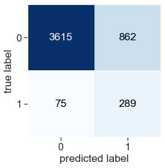

```python
# generate classification/Accuracy Report using Base/Original Model

print(classification_report(Y_test, test_preds))
print('Accuracy-Base Model :',  accuracy_score(Y_test,test_preds))


# Create Confusion Matrix using original Model- Performance of the Classifier

actual = Y_test
predicted = test_preds

results_base = confusion_matrix(actual, predicted)

# Confusion Matrix
#  TP,FN
#  FP,TN
# Accuracy = (TP+TN)/(TP+TN+FP+FN)
# Recall: = TP  / (TP +FN)- Our focus metrc- tat reduce the false negatives
# Precision = TP /(TP+FP)

print ("Confusion Matrix- Base Model:")
print(results_base)


from mlxtend.plotting import plot_confusion_matrix
fig, ax = plot_confusion_matrix(conf_mat=results_base)
plt.show()
```

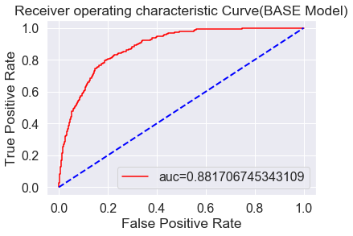

```python
# Let's draw ROC Curve using Original Model

#Receiver Operating Characteristic(ROC) curve is a plot of the true positive rate against the false positive rate.
# It shows the tradeoff between sensitivity and specificity.
#tpr (True Positive Rate) = # True positives / # positives = Recall = TP / (TP+FN)
#fpr(False Positive Rate) = # False Positives / # negatives = FP / (FP+TN)

#AUC score for the case is 0.88

y_pred_prob = base_model.predict_proba(X_test)[::,1]
fpr, tpr, _ = metrics.roc_curve(Y_test,  y_pred_prob)
auc = metrics.roc_auc_score(Y_test, y_pred_prob)

plt.figure()
lw = 2
plt.plot(fpr,tpr,color = 'red',label="auc="+str(auc))
plt.plot([0, 1], [0, 1], color='blue', lw=lw, linestyle='--')
plt.xlabel('False Positive Rate')
plt.ylabel('True Positive Rate')
plt.title('Receiver operating characteristic Curve(BASE Model)')

plt.legend(loc=4)
plt.show()
```

## Analyze Results of Final Model)

```
              precision    recall  f1-score   support

         0.0       0.98      0.81      0.89      4477
         1.0       0.25      0.79      0.38       364

    accuracy                           0.81      4841
   macro avg       0.62      0.80      0.63      4841
weighted avg       0.92      0.81      0.85      4841

Accuracy-FINAL Model : 0.8068580871720719
Confusion Matrix :FINAL Model
[[3617  860]
 [  75  289]]
```

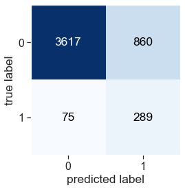

```python
# generate classification/Accuracy Report using Tuned Model
# f1-score- weitghted average of precision and Recall

print(classification_report(Y_test, test_preds_grid))
print('Accuracy-FINAL Model :',  accuracy_score(Y_test,test_preds_grid))


# Create Confusion Matrix using Tuned Model

actual = Y_test
predicted = test_preds_grid

results_final = confusion_matrix(actual, predicted)

# Confusion Matrix
#  TP,FN
#  FP,TN
# Accuracy = (TP+TN)/(TP+TN+FP+FN)
# Recall: = TP  / (TP +FN)- Our focus metrc- tat reduce the false negatives
# Precision = TP /(TP+FP)

print ("Confusion Matrix :FINAL Model")
print(results_final)

# Draw Confusion Matrix
from mlxtend.plotting import plot_confusion_matrix

fig, ax = plot_confusion_matrix(conf_mat=results_final)
plt.show()
```

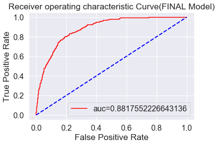

```python
# Let's draw ROC Curve using FINAL Model

#Receiver Operating Characteristic(ROC) curve is a plot of the true positive rate against the false positive rate.
# It shows the tradeoff between sensitivity and specificity.
#tpr (True Positive Rate) = # True positives / # positives = Recall = TP / (TP+FN)
#fpr(False Positive Rate) = # False Positives / # negatives = FP / (FP+TN)

#AUC score for the case is 0.88

y_pred_prob = grid_mod.predict_proba(X_test)[::,1]
fpr, tpr, _ = metrics.roc_curve(Y_test,  y_pred_prob)
auc = metrics.roc_auc_score(Y_test, y_pred_prob)

plt.figure()
lw = 2
plt.plot(fpr,tpr,color = 'red',label="auc="+str(auc))
plt.plot([0, 1], [0, 1], color='blue', lw=lw, linestyle='--')
plt.xlabel('False Positive Rate')
plt.ylabel('True Positive Rate')
plt.title('Receiver operating characteristic Curve(FINAL Model)')

plt.legend(loc=4)
plt.show()
```

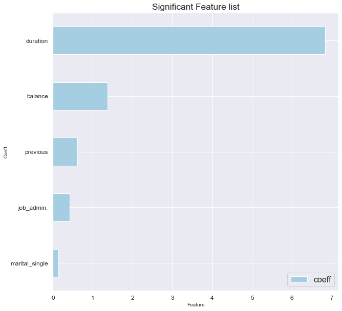

```python
#  get the weights of all the variables to know which features has most influence on predicted outcome

final_coeff = final_model.best_estimator_.coef_
df = pd.DataFrame(data=final_coeff,columns = X.columns)
df = df.stack().reset_index()
df.columns=['dummy', 'feature', 'coeff']
df.drop(['dummy'], axis = 1, inplace = True)

# 10 largest values in column age
df_5 = df.nlargest(5, ['coeff'])
df_5.set_index('feature', inplace = True)
df_sort = df_5.sort_values(by=['coeff'])

# Plot bar chart
ax = df_sort.plot(kind='barh', title ="Significant Feature list", figsize=(10, 10), fontsize=12, colormap='Paired')
ax.set_xlabel("Feature", fontsize=10)
ax.set_ylabel("Coeff", fontsize=10)
```

```python
#  get the weights of all the variables to know which features has most influence on predicted outcome

df_sort.head()
```

| feature | coeff |
| --- | --- |
| marital_single | 0.140585 |
| job_admin. | 0.420125 |
| previous | 0.616075 |
| balance | 1.369324 |
| duration | 6.830862 |